# Comparing Binomial Distribution with Different Parameters

Applied Statistics

[name]

2025-02-17

# Syllabus Reminders

- You must submit your worksheet individually by end-of-class or end-of-day. Your name must exist in your worksheet and the names of your collaborators.
- Worksheets are marked mostly on completion, and partially on correctness. It will be marked either pass or fail, there will no detailed feedback on worksheets, and no opportunities for revisions and make-up.

# Instructions

- For the exercises, please provide your answers in full sentences.
- Write your answers by replacing the text “[Write your answer here]”.
- Whenever a problem asks you to run something in R, create an R code chunk and write your R commands inside that chunk.
- If a problem requires modifying an existing R code chunk, make the necessary changes at the appropriate lines within the given code.
- Please read the problems fully and carefully before answering.
- When finished, knit this `.Rmd` to `.html`.
- Submit this `.Rmd` and the recently knitted `.html` to Moodle.

# Packages

The following R packages have already been loaded for you, so there’s no need to load them yourself—they will be used in the problem sets. If you need any additional packages, you can load them here as well.

```r
# load packages
library(tidyverse)
```

# Collaborators

# Exercises

## Problem 1

The following code simulates the Binomial distribution, with a success probability of $p=0.50$ and $n=10$ to be the number of trials.

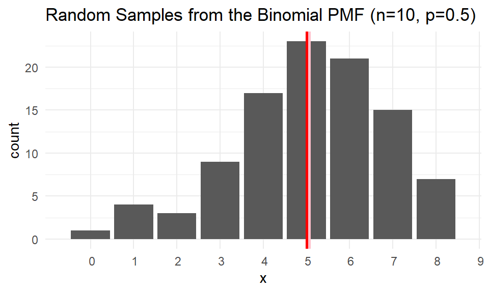

```r
# set seed for reproducibility
set.seed(42)

# set parameters, outcomes, and probabilities
N <- 100 # number of simulations
n <- 10
p <- 0.5 # set "success" probability
x_outcomes <- seq(0,10,1) # set outcome from 0 to 10 (technically infinite)
binom_samples <- rbinom(N,n,p) # function `rbinom()` is the sampling from Binomial PMF
df <- tibble(x=binom_samples) # convert to tibble

# plot the Bernoulli distribution and store it into a R variable
p1 <- ggplot(df,aes(x=x)) +
  geom_bar() +
  geom_vline(xintercept = mean(df$x), color="pink", linewidth=1) +
  geom_vline(xintercept = n*p, color="red", linewidth=1) +
  ggtitle(paste("Random Samples from the Binomial PMF (n=",n,", p=",p,")",sep="")) + # sets the title of the plot
  scale_x_discrete(limits=x_outcomes) +
  theme_minimal() # set theme of entire plot

# display plot
p1
```

1. $p_1 = 0.25$
2. $p_2 = 0.50$
3. $p_3 = 0.75$